# ELISAVA MADD Data Collection MRLL 04

Marta Royo-Llonch

Feb 3rd, 2025

# Introduction

This is an example on how to approach data analysis in R for MADD Data Collection students. We are working with an air quality dataset published by Ennio Gambi (2020) in [Mendeley datasets](https://data.mendeley.com/datasets/kn3x9rz3kd/1). This is the intro provided by the author:

*The variation in indoor gas concentration over time is monitored and data is stored in order to use this information to evaluate the type of activity carried out in the room. Thanks to the use of artificial intelligence, a quantitative approach in determining the gas concentration was avoided, which would have required careful calibration of the sensors. The dataset contains the values acquired by an array of 6 low cost sensors in successive instants of time, and the stored values are associated with the particular action that generated them. Through an appropriate data processing, based on machine learning algorithms, after an initial training phase it is possible to recognize the actions that are carried out inside the home.*

The dataset’s purpose differs from ours but we can use it lightly to understand the dynamics of doing data analysis in R.

To work in an organized manner, our working directory `MADD_DC_04` contains the following structure:

- this coding file `MADD_DC_MRLL_04_20250203.Rmd`
- `data` directory, with all the datasets we want to use in our analysis
- `output` directory, where we will save processed data and plots

Remember to adapt the path of your working directory in `line 12` of this file, inside the `setwd()` command.

## 0. Loading packages/libraries

R language contains packages (or libraries) with customised functions that let us do certain actions with ease. In this case, we will use `tidyverse` for coding functions. Plots will be done with package `ggplot2` that is embedded within `tidyverse`. The package `knitr` is essential to render this document into `html` format.

**IMPORTANT:** if it’s the first time you are using R studio you will need to install the packages before loading them. You can do that typing `install.packages("knitr")` and `install.packages("tidyverse")` in the Console window (bottom-left).

Once you have installed the packages, proceed with loading them:

```r
library(knitr)
library(tidyverse)
```

## 1. Loading the data

We have downloaded our dataset in `comma separated values, csv` format from [kaggle](https://www.kaggle.com/datasets/saurabhshahane/adl-classification?resource=download). Remember to store this dataset into your `data` directory within the `MADD_DC_04` directory.

Important info about the dataset structure:

*Each sample is made up of 7 values; the first six values are the sensor outputs, while the last is the index of the action that generated the values acquired by the sensors. The four different situations are associated with a fairly different composition of the air, taking into account that any activity produces chemical substances due, that is, to human respiration, to the exhalations of metabolic processes, to the release of volatiles by combustion and / or oxidation, and evaporation of household detergents.*

Before loading we can preview our dataset to check if it includes column headers (in apps like TextEdit, Terminal, Excel, etc). In this case it does not include column titles so we make sure to load the dataset specifying it using `header=FALSE`:

```r
data <- read.csv("data/dataset.csv",header=FALSE)
head(data)
```

```
##    V1  V2   V3   V4   V5   V6 V7
## 1 670 696 1252 1720 1321 2431  4
## 2 641 674 1156 1652 1410 2433  4
## 3 642 646 1159 1643 1455 2361  4
## 4 640 590 1105 1608 1459 2427  4
## 5 616 627 1192 1637 1466 2447  4
## 6 780 896 1438 1813 1489 2434  4
```

In the description of the dataset, the author explains the dimensions (number of columns and samples/rows) of the dataset. It is the first thing we need to check when we load our dataset. It should contain 7 columns and 1845 rows:

```r
str(data)
```

```
## 'data.frame':    1845 obs. of  7 variables:
##  $ V1: int  670 641 642 640 616 780 639 564 797 740 ...
##  $ V2: int  696 674 646 590 627 896 588 646 873 768 ...
##  $ V3: int  1252 1156 1159 1105 1192 1438 1050 1231 1289 1192 ...
##  $ V4: int  1720 1652 1643 1608 1637 1813 1583 1717 1744 1720 ...
##  $ V5: int  1321 1410 1455 1459 1466 1489 1519 1523 1544 1567 ...
##  $ V6: int  2431 2433 2361 2427 2447 2434 2450 2476 2405 2454 ...
##  $ V7: int  4 4 4 4 4 4 4 4 4 4 ...
```

The function `str()` allows us to see the dimensions and the type of variables within our dataset. In data analysis, `variables` stand for columns, and can be categorised into different typologies. In our case, all the loaded variables are `integers` or `int`.  
## 2. Setting up our working dataset

We need to arrange our dataset for further analyses, like assigning column headers and understanding the meaning of the values. The author gives us more detailed info to understand the data and metadata that we are using:

*The presence of chemicals in the air is determined through a series of electrochemical gas sensors that have been selected based on the stated technical specifications on the ability to detect classes of compounds. The sensor set can be grouped into two main categories:*

- *MQ sensors (MQ2, MQ9, MQ135, MQ137, MQ138) which have great sensitivity, low latency and low cost; each sensor can respond to different gases;*
- *Analog CO2 gas sensor (MG-811) which has excellent sensitivity to carbon dioxide and is scarcely affected by the temperature and humidity of the air.*

*The dataset contains 1845 collected samples describing 4 target situations:*

- *1 - Normal situation - Activity: clean air, a person sleeping or studying or resting - Samples: 595*
- *2 - Preparing meals - Activities: cooking meat or pasta, fried vegetables. One or two people in the room, forced air circulation - Samples: 515*
- *3 - Presence of smoke - Activity: burning paper and wood for a short period of time in a room with closed windows and doors - Example: 195*
- *4 - Cleaning - Activity: use of spray and liquid detergents with ammonia and / or alcohol. Forced air circulation can be activated or deactivated - Samples: 540*

Now we can assign column headers:

```r
#strategy 01 using base R language
#colnames(data) <- c("MQ2","MQ9","MQ135","MQ137","MQ138","MG811","Target_situations")

#strategy 02 using tidyverse
data <- data %>%
                rename(MQ2=V1,
                       MQ9=V2,
                       MQ135=V3,
                       MQ137=V4,
                       MQ138=V5,
                       MG811=V6,
                       Target_situations=V7)

##it does not make sense that different situations are numbers and not categories, let's transform integers to factors
data <- data %>%
                mutate(Target_situations=factor(Target_situations))
head(data)
```

```
##   MQ2 MQ9 MQ135 MQ137 MQ138 MG811 Target_situations
## 1 670 696  1252  1720  1321  2431                 4
## 2 641 674  1156  1652  1410  2433                 4
## 3 642 646  1159  1643  1455  2361                 4
## 4 640 590  1105  1608  1459  2427                 4
## 5 616 627  1192  1637  1466  2447                 4
## 6 780 896  1438  1813  1489  2434                 4
```

We still need to translate the target situations into metadata that is useful for us in our analysis stream. To do so, we are joining our nice metadata file (that we have previously prepared considering the information of situations 1-4 provided by the author) to our dataset. In order to join 2 data tables (or `data.frame` in R), we need them to share one common column (or `variable` in R).

Let’s first load the metadata file:

```r
metadata <- read.table("data/MADD_DC_04_20250203_Metadata.txt",
                       header=TRUE, #our file contained headers
                       sep="\t", #the field separator in this file is tab or \t
                       stringsAsFactors=TRUE) #our text/character values are transformed into factors

metadata$Target_situations <- as.factor(metadata$Target_situations)#it does not make sense that different situations are numbers

str(metadata)
```

```
## 'data.frame':    4 obs. of  8 variables:
##  $ Target_situations: Factor w/ 4 levels "1","2","3","4": 1 2 3 4
##  $ TS_tag           : Factor w/ 4 levels "Cleaning","Normal",..: 2 3 4 1
##  $ TS_Activity      : Factor w/ 4 levels "burning paper and wood for a short period of time in a room with closed windows and doors",..: 2 3 1 4
##  $ TS_HumanAction_YN: Factor w/ 2 levels "No","Yes": 1 2 2 2
##  $ TS_HumanAction_ID: Factor w/ 4 levels "Ammonia_Alcohol",..: 4 3 2 1
##  $ TS_Ventilation   : Factor w/ 3 levels "Mixed","No","Yes": 2 3 2 1
##  $ TS_PMS           : Factor w/ 2 levels "No","Yes": 1 2 2 2
##  $ TS_VOC           : Factor w/ 2 levels "No","Yes": 1 1 2 2
```

Let’s join our data and metadata objects with function `left_join`:

```r
working.data <- data %>%
                left_join(metadata,
                          by="Target_situations")

str(working.data)
```

```
## 'data.frame':    1845 obs. of  14 variables:
##  $ MQ2              : int  670 641 642 640 616 780 639 564 797 740 ...
##  $ MQ9              : int  696 674 646 590 627 896 588 646 873 768 ...
##  $ MQ135            : int  1252 1156 1159 1105 1192 1438 1050 1231 1289 1192 ...
##  $ MQ137            : int  1720 1652 1643 1608 1637 1813 1583 1717 1744 1720 ...
##  $ MQ138            : int  1321 1410 1455 1459 1466 1489 1519 1523 1544 1567 ...
##  $ MG811            : int  2431 2433 2361 2427 2447 2434 2450 2476 2405 2454 ...
##  $ Target_situations: Factor w/ 4 levels "1","2","3","4": 4 4 4 4 4 4 4 4 4 4 ...
##  $ TS_tag           : Factor w/ 4 levels "Cleaning","Normal",..: 1 1 1 1 1 1 1 1 1 1 ...
##  $ TS_Activity      : Factor w/ 4 levels "burning paper and wood for a short period of time in a room with closed windows and doors",..: 4 4 4 4 4 4 4 4 4 4 ...
##  $ TS_HumanAction_YN: Factor w/ 2 levels "No","Yes": 2 2 2 2 2 2 2 2 2 2 ...
##  $ TS_HumanAction_ID: Factor w/ 4 levels "Ammonia_Alcohol",..: 1 1 1 1 1 1 1 1 1 1 ...
##  $ TS_Ventilation   : Factor w/ 3 levels "Mixed","No","Yes": 1 1 1 1 1 1 1 1 1 1 ...
##  $ TS_PMS           : Factor w/ 2 levels "No","Yes": 2 2 2 2 2 2 2 2 2 2 ...
##  $ TS_VOC           : Factor w/ 2 levels "No","Yes": 2 2 2 2 2 2 2 2 2 2 ...
```

## 3.Data reshaping

```r
working.data.long <- working.data %>%
                          #reordering columns
                          rownames_to_column(var="Sampling_event")%>%
                          mutate(Sampling_event=as.numeric(Sampling_event))%>%
                          #reshaping
                          pivot_longer(cols = c("MQ2", "MQ9", "MQ135", "MQ137", "MQ138", "MG811"),
                                       names_to = "Sensor",
                                       values_to = "Reading")%>%
                          #new variable based on condition
                          mutate(Sensor_type=ifelse(grepl("MQ",Sensor),"LowCost","Reference"))%>%
                          #reordering columns
                          select(Sampling_event,Sensor,Sensor_type,Reading,everything())

str(working.data.long)
```

```
## tibble [11,070 × 12] (S3: tbl_df/tbl/data.frame)
##  $ Sampling_event   : num [1:11070] 1 1 1 1 1 1 2 2 2 2 ...
##  $ Sensor           : chr [1:11070] "MQ2" "MQ9" "MQ135" "MQ137" ...
##  $ Sensor_type      : chr [1:11070] "LowCost" "LowCost" "LowCost" "LowCost" ...
##  $ Reading          : int [1:11070] 670 696 1252 1720 1321 2431 641 674 1156 1652 ...
##  $ Target_situations: Factor w/ 4 levels "1","2","3","4": 4 4 4 4 4 4 4 4 4 4 ...
##  $ TS_tag           : Factor w/ 4 levels "Cleaning","Normal",..: 1 1 1 1 1 1 1 1 1 1 ...
##  $ TS_Activity      : Factor w/ 4 levels "burning paper and wood for a short period of time in a room with closed windows and doors",..: 4 4 4 4 4 4 4 4 4 4 ...
##  $ TS_HumanAction_YN: Factor w/ 2 levels "No","Yes": 2 2 2 2 2 2 2 2 2 2 ...
##  $ TS_HumanAction_ID: Factor w/ 4 levels "Ammonia_Alcohol",..: 1 1 1 1 1 1 1 1 1 1 ...
##  $ TS_Ventilation   : Factor w/ 3 levels "Mixed","No","Yes": 1 1 1 1 1 1 1 1 1 1 ...
##  $ TS_PMS           : Factor w/ 2 levels "No","Yes": 2 2 2 2 2 2 2 2 2 2 ...
##  $ TS_VOC           : Factor w/ 2 levels "No","Yes": 2 2 2 2 2 2 2 2 2 2 ...
```

## 4.Data analysis

In this section we perform various analyses and visualizations to explore our air quality data. We start by summarising the sensor readings by grouping according to sensor type and the activity (or situation) during which the readings were recorded. Then we create different plots to visualise temporal trends, distributions, and differences between the low???cost and reference sensors.

### 4.1 Summarising sensor readings

We start by calculating basic statistics for our sensor readings across different activities:

We first group the data by two variables: `Sensor_type` (i.e., LowCost or Reference) and `Target_situations` (the code for each activity). Then, we summarise the readings by calculating the mean, standard deviation, and median CO??? values for each group. Finally, we ungroup the data so that subsequent operations are not limited by these groupings.

The `group_by` function allows us to analyze patterns separately for each sensor category and activity combination. This helps identify which activities produce the most variable sensor responses.

This step helps us to compare sensor performance across different activities.

```r
working.data.long %>%
        group_by(Sensor_type,Target_situations)%>%
        summarise(Mean_CO2=mean(Reading),
                  SD_CO2=sd(Reading),
                  Median_CO2=median(Reading))%>%
        ungroup()
```

```
## # A tibble: 8 × 5
##   Sensor_type Target_situations Mean_CO2 SD_CO2 Median_CO2
##   <chr>       <fct>                <dbl>  <dbl>      <dbl>
## 1 LowCost     1                     861.  399.        895
## 2 LowCost     2                    1038.  407.       1140
## 3 LowCost     3                    1312.  399.       1438
## 4 LowCost     4                    1221.  418.       1296
## 5 Reference   1                    2311.  118.       2292
## 6 Reference   2                    2239.  137.       2186
## 7 Reference   3                    1931.   96.4      1904
## 8 Reference   4                    2296.  180.       2332.
```

### 4.2 Time Series Visualization

This code block creates a time series plot for CO??? readings, with different colors representing activity types. The plot reveals how different activities create distinct sensor response patterns over time.

- `geom_line()` draws a transparent line connecting the readings (using an alpha of 0.3) to show overall trends over the sampling events.
- `geom_point()` adds individual points to highlight each observation, with colors representing the activity type (TS_tag).
- The `labs()` function is used to add a title, subtitle, and axis labels.
- We use `theme_minimal()` for a clean look and adjust the legend???s position.
- Finally, `facet_wrap()` splits the plot by Sensor (each sensor gets its own panel arranged in a single column), and the scales = “free_y” argument lets each sensor???s plot have its own y-axis scale.

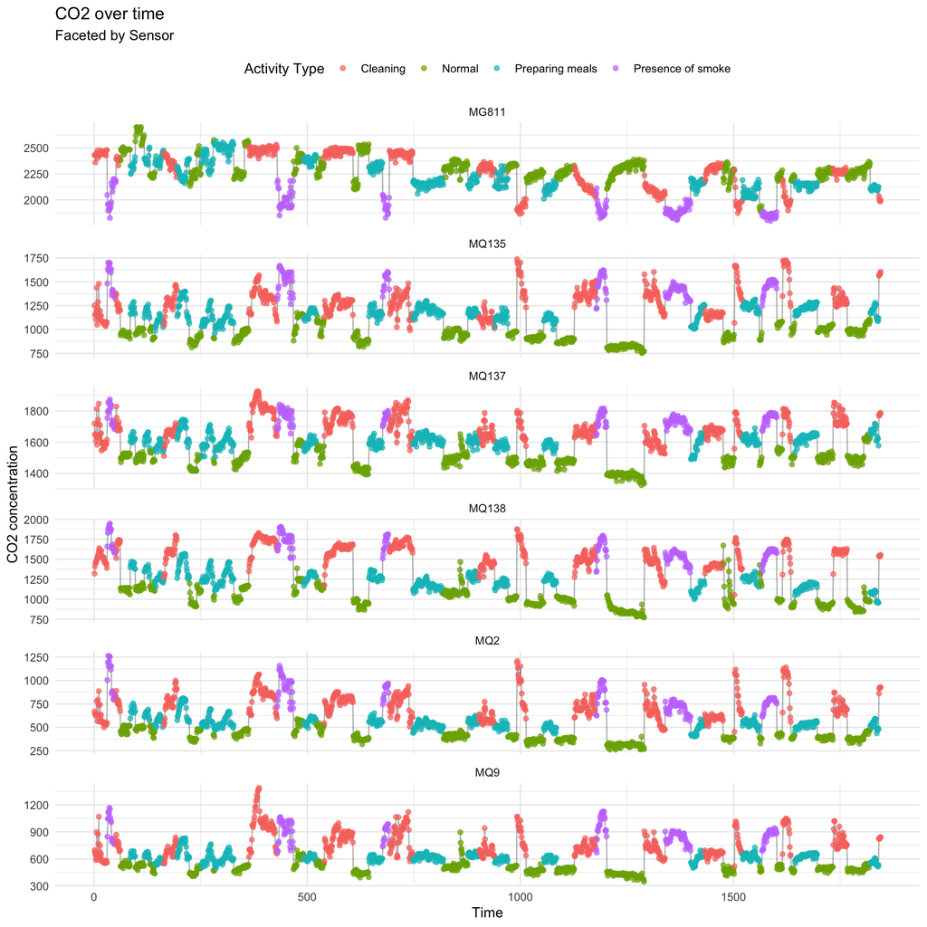

```r
working.data.long %>%
        ggplot()+
                geom_line(aes(x=Sampling_event,
                                 y=Reading),
                           alpha=0.3)+
                geom_point(aes(x=Sampling_event,
                                 y=Reading,
                                 group=interaction(TS_tag,Sensor),
                                 col=TS_tag),
                           alpha=0.7)+
                labs(title = "CO2 over time",
                       subtitle = "Faceted by Sensor",
                       x = "Time",
                       y = "CO2 concentration",
                       color = "Activity Type") +
                theme_minimal()+
                theme(legend.position = "top")+
                facet_wrap(vars(Sensor),ncol=1,scales="free_y")
```

```r
# ggsave("output/Co2_time_series_by_activity.pdf",
#        dpi=150,width=200,height=400,
#        units="mm",
#        device=cairo_pdf)
```

### 4.3 Boxplots: Sensor readings by activity type (grouped by sensor type)

In this visualization, we compare the distribution of sensor readings across different activities. This boxplot comparison helps us:

- Assess measurement ranges between sensor types
- Identify activity-specific response patterns
- Compare measurement variability (box height)

The faceting separates LowCost and Reference sensors for clearer comparison. Notice how Reference sensors (MG811) show tighter interquartile ranges, suggesting more consistent measurements.

Regarding the code:

- `geom_boxplot()` creates boxplots for each activity type (`TS_tag`), grouped by sensor type (using `interaction(TS_tag, Sensor_type)`), and colors them by `Sensor_type`.
- `facet_wrap(vars(Sensor_type))` creates separate panels for low-cost and reference sensors, making it easier to compare the statistical summaries (such as medians and quartiles) between the two sensor categories.

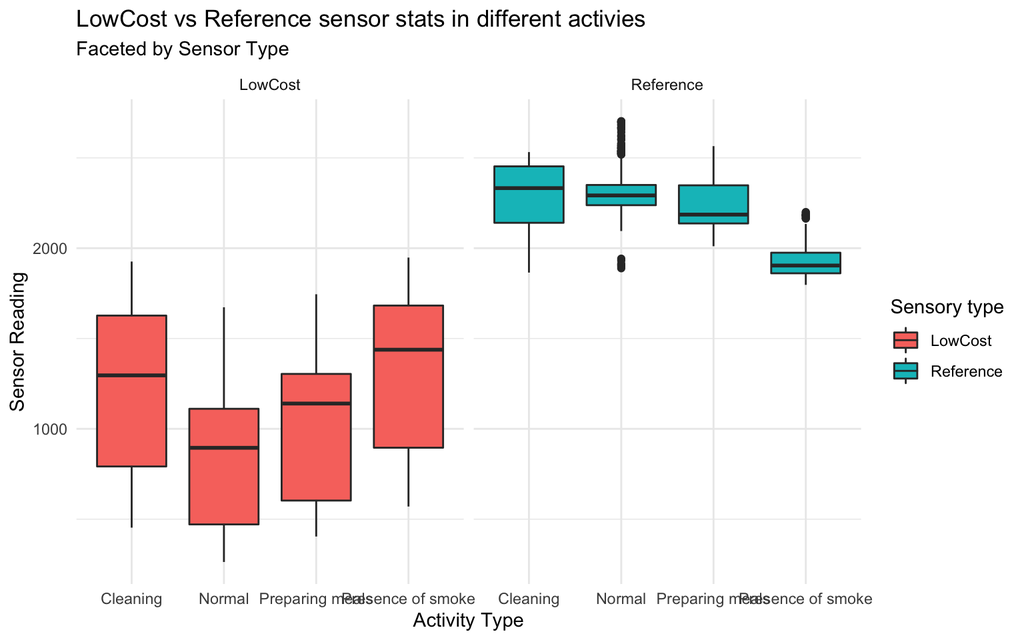

```r
working.data.long %>%
        ggplot()+
                geom_boxplot(aes(x=TS_tag,
                                 y=Reading,
                                 group=interaction(TS_tag,Sensor_type),
                                 fill=Sensor_type))+
                labs(title = "LowCost vs Reference sensor stats in different activies",
                       subtitle = "Faceted by Sensor Type",
                       x = "Activity Type",
                       y = "Sensor Reading",
                       fill = "Sensory type") +
                theme_minimal()+
                facet_wrap(vars(Sensor_type))
```

```r
# ggsave("output/Boxplot_sensortype_by_activity.pdf",
#        dpi=150,width=200,height=100,
#        units="mm",
#        device=cairo_pdf)
```